# beta

2024-02-08

```r
library(here)
source(here("base","src.R"))

library(ggnewscale)
```

# Questions

1. We measure beta at the scale of each treatment and we need beta to optimize our model. Does this mean our sample size is now the number of treatments (i.e., 9)?
2. Or can we estimate Beta now using foraging rate? But how would we optimize per-spore susceptibility?

We’ll grab our estimates for Beta to use for our optimizer and we’ll use the best fitting model to determine foraging rate at each temperature.

```r
beta_summ <- readRDS(here("processed_data", "beta_summary.rds"))
beta_summ %<>% filter(temp %in% const_temp) %>% filter(species == "D") %>% mutate(temp = as.numeric(temp))
```

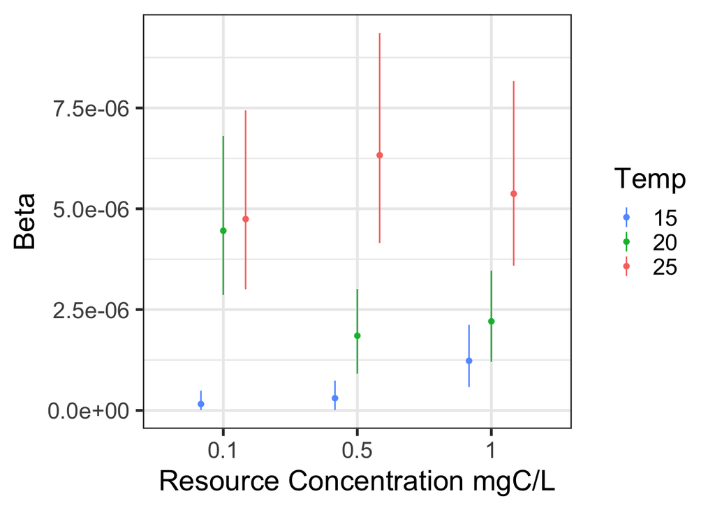

```r
beta_summ %>% ggplot(.,aes(x=as.factor(resource),y=beta.est, color=as.factor(temp))) +
  geom_point(aes(), position = position_dodge(width = 0.5)) +
  geom_linerange(aes(ymin=beta.025, ymax=beta.975), position = position_dodge(width = 0.5)) +
  scale_color_manual(values = c("#619CFF", "#00BA38", "#F8766D")) +
  labs(y = "Beta", x = "Resource Concentration mgC/L", color="Temp")
```

```r
aic_f <- readRDS(here("mle", "aic_table.rds"))
aic_f
```

```
##                logLik AIC    dLogLik dAIC   df weight
## m7c_EXP_EXP     -84.5  179.0  137.2     0.0 5  0.417
## m6c_h(T)~EXP    -86.2  180.3  135.5     1.3 4  0.216
## m7d_LIN_EXP     -85.4  180.8  136.3     1.8 5  0.172
## m6b_h(T)~LIN    -87.1  182.3  134.5     3.3 4  0.081
## m7e_EXP_LIN     -87.1  184.3  134.5     5.3 5  0.030
## m7b_LIN-LIN     -87.2  184.3  134.5     5.3 5  0.030
## m5c_arr(R)~EXP  -88.5  185.0  133.2     5.9 4  0.021
## m4_full         -89.5  185.1  132.2     6.0 3  0.020
## m5b_arr(R)~LIN  -88.9  185.8  132.8     6.8 4  0.014
## m3_rsc         -134.3  272.7   87.3    93.7 2  <0.001
## m2_temp        -174.7  353.4   47.0   174.4 2  <0.001
## m1_size        -193.3  388.6   28.4   209.6 1  <0.001
## m0_base        -221.7  445.4    0.0   266.4 1  <0.001
```

```r
f_coefs <- coef(readRDS(here("mle", "m7c_f_fit.rds")))
f_coefs
```

```
##           f       arr_t           h           p           w
##  12.0979549  63.4553113 101.2145846  -3.4676418  -0.3235184
```

```r
z <- 200 #200 spores/mL exposure and exposed for 24 hours
exp_time <- 1 #1 day
vol <- 15 #mL
ref_t <- 15 #degrees C

f_median <- 6.897
```

We can now calculate the effective foraging rate for all of our treatments using these parameter values and this equation

This formulation assumes the coefficients from model 7c (full interaction exp-exp)

```r
get_f <- function(temp, resource){
  ref_t <- 15
  f <- as.numeric(f_coefs[1])
  arr_prime <- as.numeric(f_coefs[2])
  h_prime <- as.numeric(f_coefs[3])
  p <- as.numeric(f_coefs[4])
  w <- as.numeric(f_coefs[5])
    arr <- arr_prime*exp(p*resource)
    h <- h_prime*exp(w*temp)
    ((f*exp(arr*(1/ref_t - 1/temp)))/(1+f*exp(arr*(1/ref_t - 1/temp))*h*resource))
}
```

```r
beta_summ %<>% mutate(#f = f_median,
                      f = get_f(beta_summ$temp, beta_summ$resource)
                      )
```

We can use foraging rate to help us estimate beta and per-spore susceptibility. We now have estimates for foraging rate for all treatments and we can estimate beta using infection data.

$$\beta Z S = f u Z S \\
\beta = f u$$

Beta is the rate at which individuals become infected which depends on the foraging rate, the concentration of spores, and the probability that an individual becomes infected when encountering a spore, i.e., u.

We want to incorporate the effects of temperature and resource conditions on this as well. We can do this by getting an estimate for Beta for each treatment and using that as the objective function for our optimizer. In other words, which value of u will generate the Beta observed from the experiment?

# Model 1

In our most basic iteration, we can use the equation from before.

$$\beta = f u$$

There should be another way to do this using all the data rather than just the summarized data. The objective function should rely on the number of infected per treatment which relies on beta which relies on u.

```r
fitness <- read.csv(here("raw_data/main_fitness_edit.csv")) #must be read.csv
fitness %<>% dplyr::select(tube, temp_id, REMOVED, KBP, final_date)
mort <-  read_csv(here("raw_data/main_mort_edit.csv"))
dataset <- left_join(mort,fitness)
```

This chunk removes individuals with NA for “inf”. These ones we were unsure whether they were infected because they died too early to check for infection or went missing.

```r
dataset %<>% filter(species == "D") %>% #only daphnia for this analysis
  filter(temp %in% const_temp) #only constant temp for this analysis

dataset %<>% mutate(birthdate = ifelse(species == "daphnia", "4/5/22", "4/6/22"),
                    lifespan = as.numeric(mdy(final_date) - mdy(birthdate)),
                    temp = as.numeric(temp),
                    treatment = paste(temp, resource, sep = "_")) %>%
  filter(is.na(male)) %>% #remove males
  filter(is.na(missing)) %>% #remove missing
  filter(!is.na(inf)) #remove NAs for inf for estimating beta. sometimes they died too young to tell
```

We can measure prevalence AKA probability of infection again because the last time it was done was with the unknown infected individuals included

```r
prob_inf <- dataset %>% group_by(temp, resource) %>% summarize(prob_inf = sum(inf)/n())
beta_summ %<>% left_join(., prob_inf)
dataset %<>% mutate(inf_status = inf, dead = ifelse(is.na(REMOVED) & is.na(KBP), 1, 0))
```

```r
dataset %<>% mutate(#f = f_median,
                    f = get_f(dataset$temp, dataset$resource)
                    )
```

```r
dataset %<>% mutate(spore_exposure = 200, #spores/mL
                    uninf = 1-inf_status,
                    time = 1, #duration of exposure in days
                    trt = paste(temp, resource, species, sep = "_"))


# will loop through all treatments:
trts <- unique(dataset$treatment)

treatments <- unique(dataset$treatment)
length(treatments) # how many unique? # this tells you how big to make the summary
```

```
## [1] 9
```

$$probability\ of\ infection = e^{-f u Zt}$$

# Need to check units

```r
m1_ll <- function(u){
  tmp <- dataset

    inf_out <- function(inf_status, f, u, spore_exposure, time){
    dbinom(x = inf_status, size = 1, prob=1-exp(-f*u*spore_exposure*time))
  }

  tmp %<>%
    mutate(ll = mapply(inf_out, inf_status = inf_status, f = f, u = u, spore_exposure = spore_exposure, time = time))
  -sum(tmp$ll)
}
```

```r
m1_u_fita <- mle2(m1_ll, start=list(u = 0.00001),
                     control=list(parscale = c(u = 0.00001)),
                     skip.hessian=F, method="L-BFGS-B", lower=0, upper=1)
      #this produces a warning: NaNs produced - not sure if this is an issue
```

```r
m1_u_fit <- mle2(uninf ~ dbinom(size = 1, prob=exp(-f*u*spore_exposure*time)),
                 data=dataset, start=list(u = 0.0000001),
                     control=list(parscale = c(u = 0.0000001)),
                     skip.hessian=F, method="L-BFGS-B", lower=0, upper=1)
```

Let’s see if this is getting a decent estimate per treatment

```r
m1_fits <- beta_summ %>% dplyr::select(temp, resource)
for (i in 1:length(treatments)){
  dsub <- dataset %>% filter(treatment == treatments[i])
  m1_fits$treatment[i] <- treatments[i]
  m1_fits$u[i] <- coef(mle2(uninf ~ dbinom(size = 1, prob=exp(-f*u*spore_exposure*time)),
                 data=dsub, start=list(u = 0.0000001),
                 control=list(parscale = c(u = 0.0000001)),
                 skip.hessian=F, method="L-BFGS-B", lower=0, upper=1))[1]
}
```

```r
beta_summ %<>% left_join(., m1_fits)
```

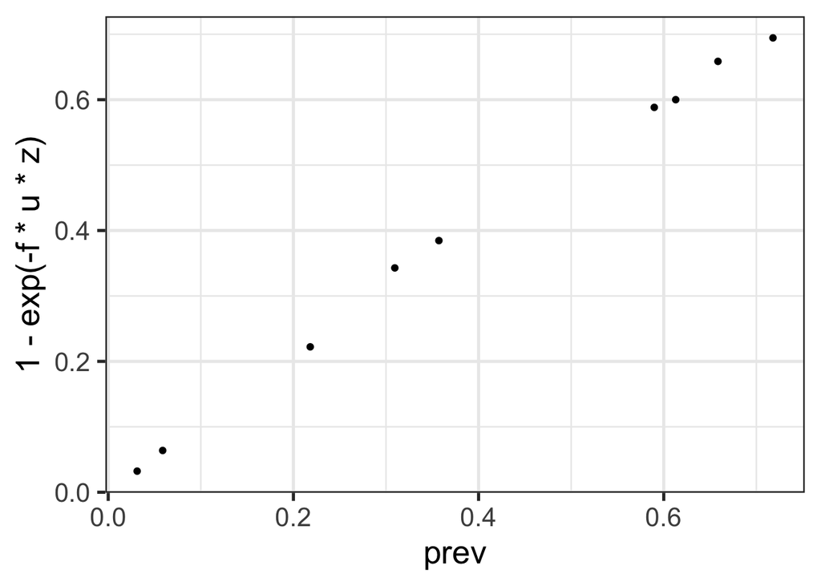

```r
beta_summ %>% ggplot(.,aes(x=prev, y=1-exp(-f*u*z))) + geom_point()
```

# Model 2

Then we can try to incorporate temperature using an Arrhenius coefficient

$$probability\ of\ infection = e^{-f u e^{T_{A}(1/T_{R}-1/T)} Zt}$$

```r
m2_ll <- function(u, arr_t){
  tmp <- dataset

    inf_out <- function(inf_status, f, u, arr_t, spore_exposure, time, temp){
    dbinom(x = inf_status, size = 1, prob=exp(-f*u*spore_exposure*time*exp(arr_t*(1/ref_t-1/temp))))
  }

  tmp %<>%
    mutate(ll = mapply(inf_out, inf_status = inf, f = f, u = u, arr_t=arr_t, spore_exposure = spore_exposure, time = time, temp = temp))
  -sum(tmp$ll)
}
```

```r
m2_u_fit <- mle2(m2_ll, start=list(u = 0.0001, arr_t = 100),
                     control=list(parscale = c(u = 0.0001, arr_t = 100)),
                     skip.hessian=F, method="L-BFGS-B",
                 lower=c(u = 0, arr_t = 0), upper=c(u = 1, arr_t = Inf))
```

```r
m2_u_fit <- mle2(uninf ~ dbinom(size = 1, prob=exp(-f*u*spore_exposure*time*exp(arr_t*(1/ref_t-1/temp)))),
                 data=dataset, start=list(u = 0.0001, arr_t = 100),
                     control=list(parscale = c(u = 0.0001, arr_t = 100)),
                     skip.hessian=F, method="L-BFGS-B",
                 lower=c(u = 0, arr_t = 0), upper=c(u = 1, arr_t = Inf))
```

```r
m2_fits <- beta_summ %>% dplyr::select(temp, resource)
for (i in 1:length(treatments)){
  dsub <- dataset %>% filter(treatment == treatments[i])
  m2_fits$treatment[i] <- treatments[i]
  model <- mle2(uninf ~ dbinom(size = 1, prob=exp(-f*u*spore_exposure*time*exp(arr_t*(1/ref_t-1/temp)))),
                 data=dsub, start=list(u = 0.00001, arr_t = 10),
                     control=list(parscale = c(u = 0.00001, arr_t = 10)),
                     skip.hessian=F, method="L-BFGS-B",
                 lower=c(u = 0, arr_t = 0), upper=c(u = 1, arr_t = Inf))
  m2_fits$m2_u[i] <- coef(model)[1]
  m2_fits$m2_arr[i] <- coef(model)[2]

}
```

```r
beta_summ %<>% left_join(., m2_fits)
```

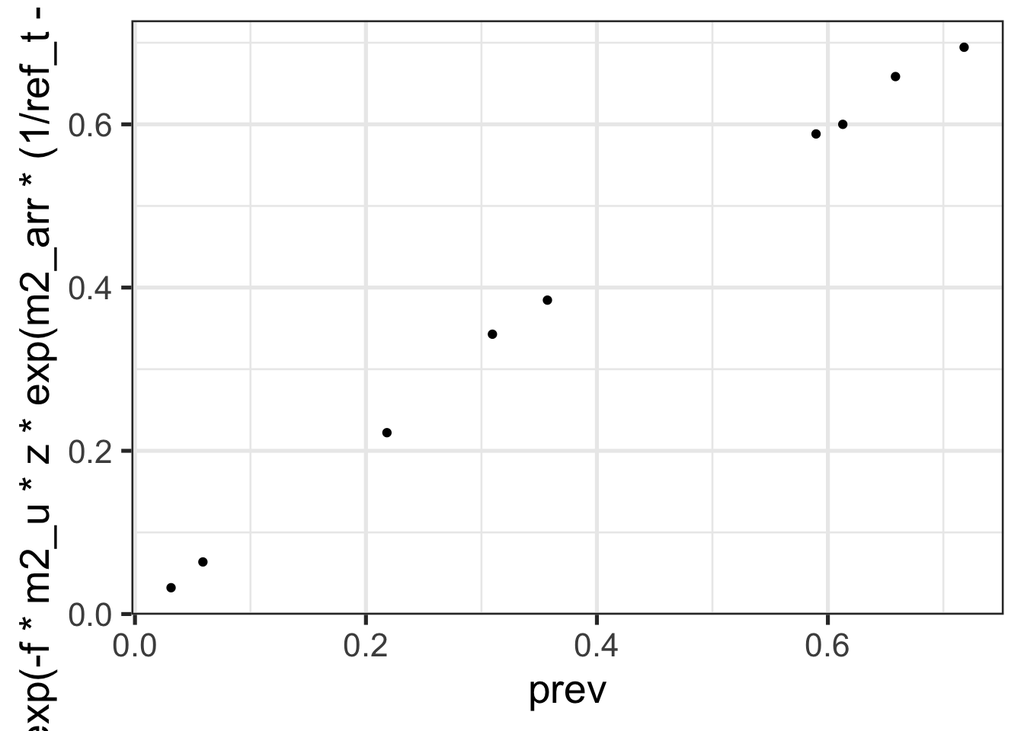

```r
beta_summ %>% ggplot(.,aes(x=prev, y=1-exp(-f*m2_u*z*exp(m2_arr*(1/ref_t-1/temp))))) + geom_point()
```

# Model 3

And try to incorporate resource using a half-saturation constant

$$probability\ of\ infection = e^{-f(\frac{uR}{k + R})Zt}$$

```r
m3_ll <- function(u, k){
  tmp <- dataset

    inf_out <- function(inf_status, f, u, k, spore_exposure, time, resource){
    dbinom(x = inf_status, size = 1, prob = exp(-f*(u*resource/(k + resource))*spore_exposure*time))
  }

  tmp %<>%
    mutate(ll = mapply(inf_out, inf_status = inf, f = f, u = u, k=k, spore_exposure = spore_exposure, time = time, resource = resource))
  -sum(tmp$ll)
}
```

```r
m3_u_fit <- mle2(m3_ll, start=list(u = 0.01, k = 1),
                     control=list(parscale = c(u = 0.01, k = 1)),
                     skip.hessian=F, method="L-BFGS-B",
                 lower=c(u = 0, k = 0), upper=c(u = 1, k = Inf))
```

```r
m3_u_fit <- mle2(uninf ~ dbinom(size = 1, prob = exp(-f*(u*resource/(k + resource))*spore_exposure*time)),
                 data=dataset, start=list(u = 0.0001, k = 1),
                     control=list(parscale = c(u = 0.0001, k = 1)),
                     skip.hessian=F, method="L-BFGS-B",
                 lower=c(u = 0, k = 0), upper=c(u = 1, k = Inf))
```

```r
m3_fits <- beta_summ %>% dplyr::select(temp, resource)
for (i in 1:length(treatments)){
  dsub <- dataset %>% filter(treatment == treatments[i])
  m3_fits$treatment[i] <- treatments[i]
  model <- mle2(uninf ~ dbinom(size = 1, prob=exp(-f*(u*resource/(k + resource))*spore_exposure*time)),
                 data=dsub, start=list(u = 0.0001, k = 1),
                     control=list(parscale = c(u = 0.0001, k = 1)),
                     skip.hessian=F, method="L-BFGS-B",
                 lower=c(u = 0, k = 0), upper=c(u = 1, k = Inf))
  m3_fits$m3_u[i] <- coef(model)[1]
  m3_fits$m3_k[i] <- coef(model)[2]

}
beta_summ %<>% left_join(., m3_fits)
```

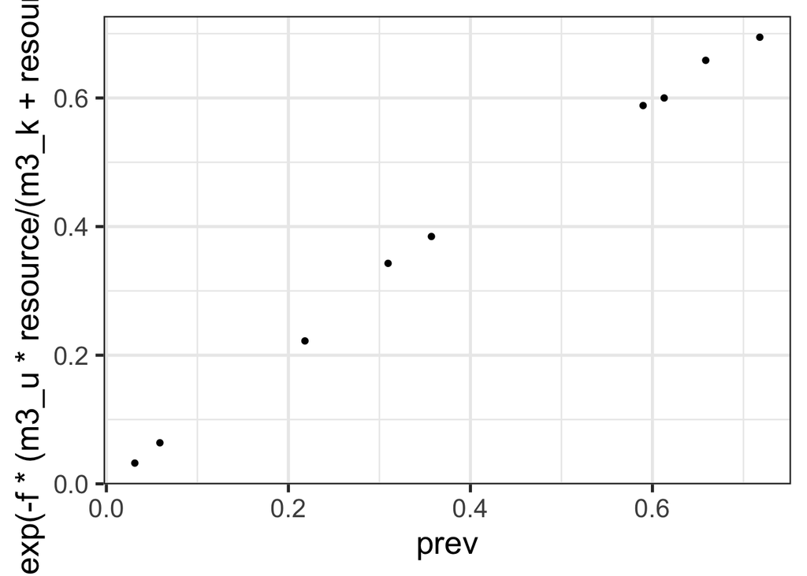

```r
beta_summ %>% ggplot(.,aes(x=prev, y=1-exp(-f*(m3_u*resource/(m3_k + resource))*z))) + geom_point()
```

# Model 4

And we can combine this to incorporate both temperature and resource-dependence

$$probability\ of\ infection = e^{-f(\frac{u e^{T_{A}(1/T_{R}-1/T)} R}{k +
R})Zt}$$

```r
m4_ll <- function(u, arr_t, k){
  tmp <- dataset

    inf_out <- function(inf_status, f, u, arr_t, k, spore_exposure, time, temp, resource){
    dbinom(x = inf_status, size = 1, prob = exp(-f*(u*exp(arr_t*(1/ref_t-1/temp))*resource/(k + resource))*spore_exposure*time))
  }

  tmp %<>%
    mutate(ll = mapply(inf_out, inf_status = inf, f = f, u = u, arr_t=arr_t, k=k, spore_exposure = spore_exposure, time = time, temp=temp, resource = resource))
  -sum(tmp$ll)
}
```

```r
m4_u_fit <- mle2(m4_ll, start=list(u = 0.001, arr_t = 10, k = 1),
                     control=list(parscale = c(u = 0.001, arr_t = 10, k = 1)),
                     skip.hessian=F, method="L-BFGS-B",
                 lower=c(u = 0, arr_t = 0, k = 0), upper=c(u = 1, arr_t = Inf, k = Inf))
```

```r
m4_u_fit <- mle2(uninf ~ dbinom(size = 1, prob = exp(-f*(u*exp(arr_t*(1/ref_t-1/temp))*resource/
                                                           (k + resource))*spore_exposure*time)),
                 data=dataset, start=list(u = 0.00001, arr_t = 10, k = 1),
                     control=list(parscale = c(u = 0.00001, arr_t = 10, k = 1)),
                     skip.hessian=F, method="L-BFGS-B",
                 lower=c(u = 0, arr_t = 0, k = 0), upper=c(u = 1, arr_t = Inf, k = Inf))
```

```r
m4_fits <- beta_summ %>% dplyr::select(temp, resource)
for (i in 1:length(treatments)){
  dsub <- dataset %>% filter(treatment == treatments[i])
  m4_fits$treatment[i] <- treatments[i]
  model <- mle2(uninf ~ dbinom(size = 1, prob=exp(-f*(u*exp(arr_t*(1/ref_t-1/temp))*resource/
                                                           (k + resource))*spore_exposure*time)),
                 data=dsub, start=list(u = 0.00001, arr_t = 10, k = 1),
                     control=list(parscale = c(u = 0.00001, arr_t = 10, k = 1)),
                     skip.hessian=F, method="L-BFGS-B",
                 lower=c(u = 0, arr_t = 0, k = 0), upper=c(u = 1, arr_t = Inf, k = Inf))
  m4_fits$m4_u[i] <- coef(model)[1]
  m4_fits$m4_arr[i] <- coef(model)[2]
  m4_fits$m4_k[i] <- coef(model)[3]
}
beta_summ %<>% left_join(., m4_fits)
```

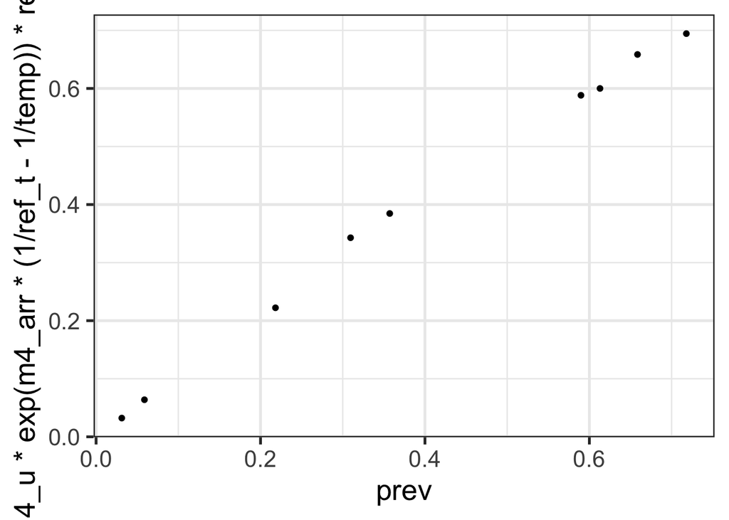

```r
beta_summ %>% ggplot(.,aes(x=prev, y=1-exp(-f*(m4_u*exp(m4_arr*(1/ref_t-1/temp))*resource/
                                                           (m4_k + resource))*z))) + geom_point()
```

```r
mod_list <- list(m1_u_fit, m2_u_fit, m3_u_fit, m4_u_fit)
AICtab(mod_list, logLik=T, base=T, weights=T)
```

```
##        logLik AIC    dLogLik dAIC   df weight
## model3 -194.4  392.8   22.5     0.0 2  0.69
## model4 -194.2  394.4   22.7     1.6 3  0.31
## model1 -216.9  435.9    0.0    43.1 1  <0.001
## model2 -216.7  437.4    0.3    44.5 2  <0.001
```

```r
mod_params <- beta_summ %>% dplyr::select(trt:treatment)
mod_params %<>% mutate(m1_u = coef(m1_u_fit)[1],
                       m2_u = coef(m2_u_fit)[1],
                       m2_arr = coef(m2_u_fit)[2],
                       m3_u = coef(m3_u_fit)[1],
                       m3_k = coef(m3_u_fit)[2],
                       m4_u = coef(m4_u_fit)[1],
                       m4_arr = coef(m4_u_fit)[2],
                       m4_k = coef(m4_u_fit)[3])
```

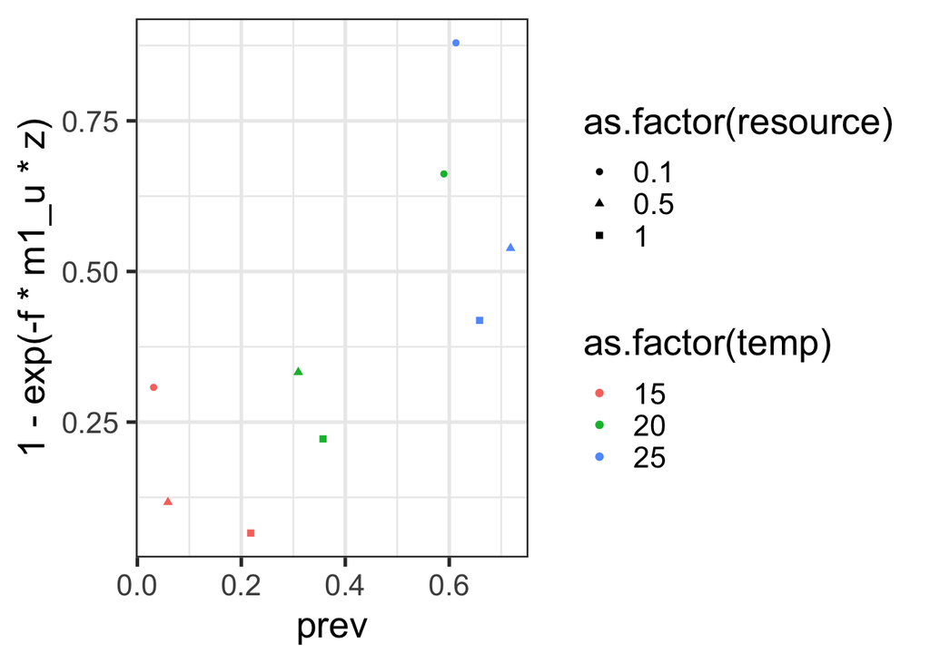

```r
mod_params %>% ggplot(.,aes(x=prev, y=1-exp(-f*m1_u*z), color = as.factor(temp), shape = as.factor(resource))) + geom_point()
```

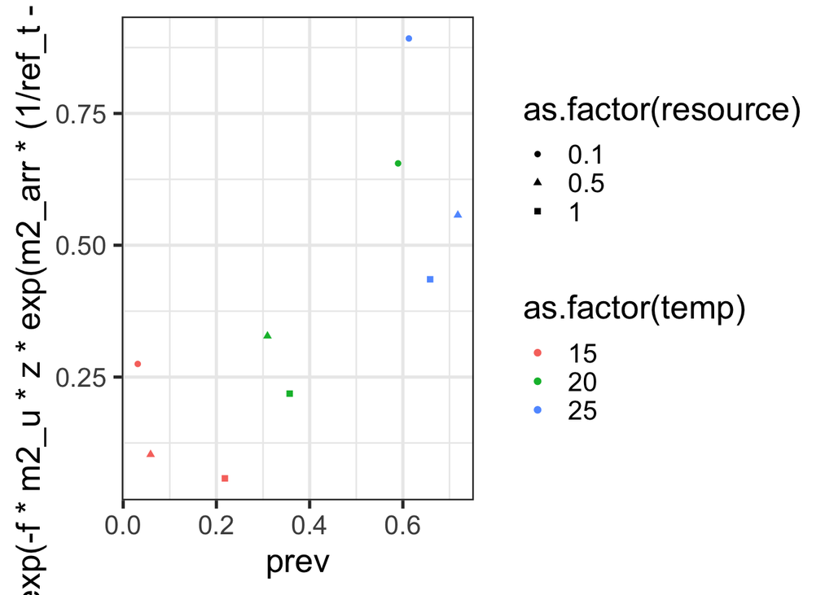

```r
mod_params %>% ggplot(.,aes(x=prev, y=1-exp(-f*m2_u*z*exp(m2_arr*(1/ref_t-1/temp))), color = as.factor(temp), shape = as.factor(resource))) + geom_point()
```

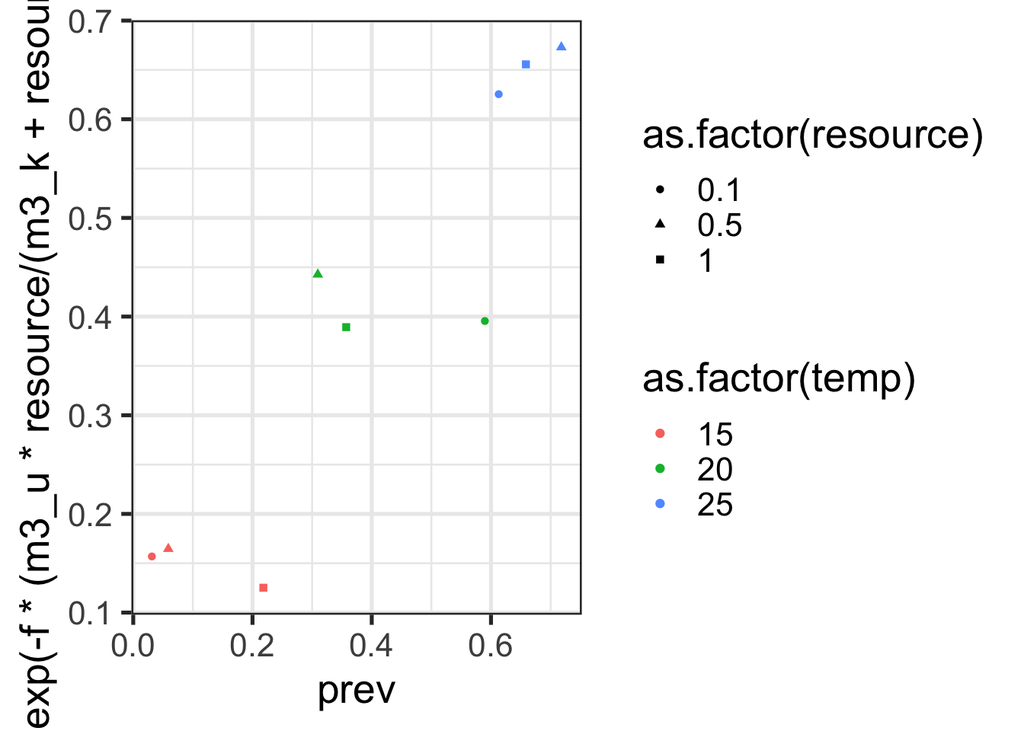

```r
mod_params %>% ggplot(.,aes(x=prev, y=1-exp(-f*(m3_u*resource/(m3_k + resource))*z), color = as.factor(temp), shape = as.factor(resource))) + geom_point()
```

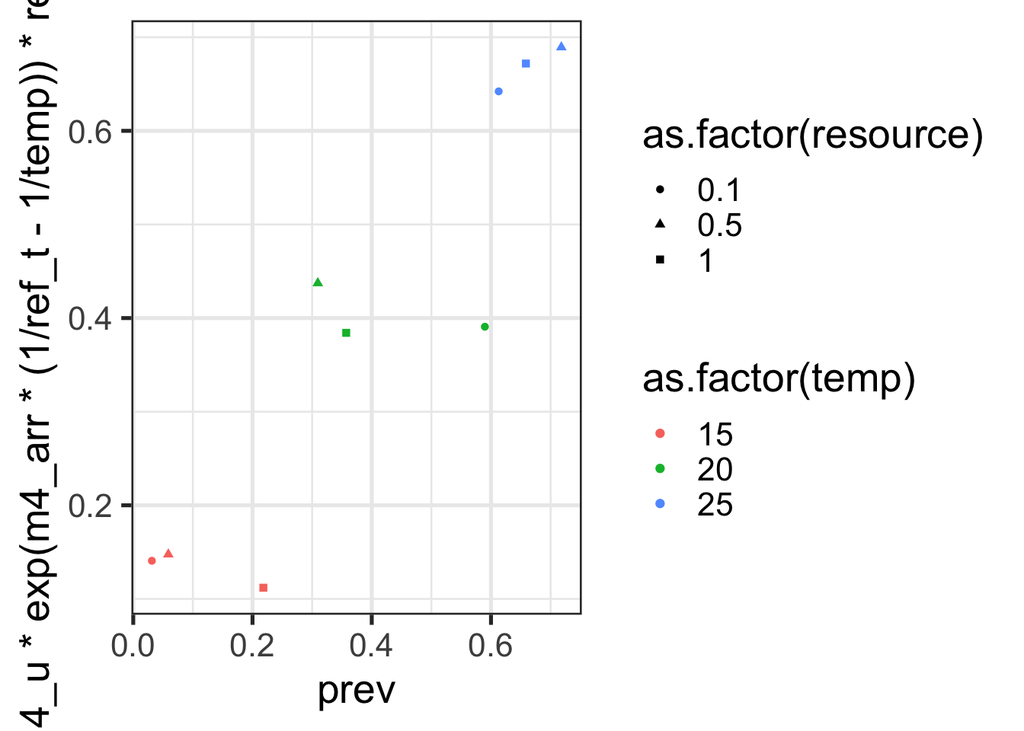

```r
mod_params %>% ggplot(.,aes(x = prev, y = 1-exp(-f*(m4_u*exp(m4_arr*(1/ref_t-1/temp))*resource/
                                                           (m4_k + resource))*z), color = as.factor(temp), shape = as.factor(resource))) + geom_point()
```

From Alex’s script for constant f and constant u

```r
#1 - exp((cfcu$u[i])*z.seq*vol*(exp(-(cfcu$f.0.hat[i]/vol)*(cfcu$length[i]^2)*cfcu$time[i])-1))
```

```r
test <- tibble(resource = seq(0,1,length.out=11),
               temp = seq(15,25,length.out=11))
test %<>% mutate(f = get_f(test$temp, test$resource))
```

```r
u <- 1
arr_t <- 25
k <- 1500
p <- -30
test %<>% mutate(m5a = exp(-f*(u*exp((arr_t+p*resource)*(1/ref_t-1/temp))*resource/(k + resource))*z*1))
```

# Models 5-7

Finally, we can also include interactions for our temperature and resource-dependent parameters so that they can interact with each other…

$$probability\ of\ infection = e^{-f(\frac{u e^{T_{A}(1/T_{R}-1/T)} R}{k +
R})Zt}$$

linearly…
$$T_{A} = {T_{A}}' + {\rho}R \\$$

```r
m5a_u_fit <- mle2(uninf ~ dbinom(size = 1, prob =
                                   exp(-f*((u*exp((arr_t+p*resource)*(1/ref_t-1/temp))*resource)/
                                             (k + resource))*spore_exposure*time)),
                 data=dataset, start=list(u = 0.001, arr_t = 1, k = 10, p=1),
                     control=list(parscale = c(u = 0.001, arr_t = 1, k = 10, p=1)),
                     skip.hessian=F, method="L-BFGS-B",
                 lower=c(u = 0, arr_t = 0, k = 0, p=-Inf), upper=c(u = 1, arr_t = Inf, k = Inf, p=Inf))
```

$$T_{A} = {T_{A}}'e^{{\rho}R}$$

```r
m5b_u_fit <- mle2(uninf ~ dbinom(size = 1, prob =
                                   exp(-f*(u*exp((arr_t*exp(p*resource))*(1/ref_t-1/temp))*resource/
                                             (k + resource))*spore_exposure*time)),
                 data=dataset, start=list(u = 0.00001, arr_t = 10, k = 1, p=0.1),
                     control=list(parscale = c(u = 0.00001, arr_t = 10, k = 1, p=0.1)),
                     skip.hessian=F, method="L-BFGS-B",
                 lower=c(u = 0, arr_t = 0, k = 0, p=-Inf), upper=c(u = 1, arr_t = Inf, k = Inf, p=Inf))
```

$$k = k' + {\omega}T$$

```r
m6a_u_fit <- mle2(uninf ~ dbinom(size = 1, prob = exp(-f*(u*exp(arr_t*(1/ref_t-1/temp))*resource/((k + w*temp) + resource))*spore_exposure*time)),
                 data=dataset, start=list(u = 0.0001, arr_t = 10, k = 0.01, w=0.01),
                     control=list(parscale = c(u = 0.0001, arr_t = 10, k = 0.01, w=0.01)),
                     skip.hessian=F, method="L-BFGS-B",
                 lower=c(u = 0, arr_t = 0, k = 0, w=-Inf), upper=c(u = 1, arr_t = Inf, k = Inf, w=Inf))
```

$$k = k'e^{{\omega}T}$$

```r
m6b_u_fit <- mle2(uninf ~ dbinom(size = 1, prob = exp(-f*(u*exp(arr_t*(1/ref_t-1/temp))*resource/((k*exp(w*temp)) + resource))*spore_exposure*time)),
                 data=dataset, start=list(u = 0.001, arr_t = 10, k = 1, w=1),
                     control=list(parscale = c(u = 0.001, arr_t = 10, k = 1, w=1)),
                     skip.hessian=F, method="L-BFGS-B",
                 lower=c(u = 0, arr_t = 0, k = 0, w=-Inf), upper=c(u = 1, arr_t = Inf, k = Inf, w=Inf))
m7a_u_fit <- mle2(uninf ~ dbinom(size = 1, prob = exp(-f*(u*exp((arr_t+p*resource)*(1/ref_t-1/temp))*resource/((k + w*temp) + resource))*spore_exposure*time)),
                 data=dataset, start=list(u = 0.001, arr_t = 10, k = 0.01, p=0.01, w=0.01),
                     control=list(parscale = c(u = 0.001, arr_t = 10, k = 0.01, p=0.01, w=0.01)),
                     skip.hessian=F, method="L-BFGS-B",
                 lower=c(u = 0, arr_t = 0, k = 0, p=-Inf, w=-Inf), upper=c(u = 1, arr_t = Inf, k = Inf, p=Inf, w=Inf))
m7b_u_fit <- mle2(uninf ~ dbinom(size = 1, prob = exp(-f*(u*exp((arr_t*exp(p*resource))*(1/ref_t-1/temp))*resource/((k*exp(w*temp)) + resource))*spore_exposure*time)),
                 data=dataset, start=list(u = 0.001, arr_t = 10, k = 1, p=0.1, w=0.1),
                     control=list(parscale = c(u = 0.001, arr_t = 10, k = 1, p=0.1, w=0.1)),
                     skip.hessian=F, method="L-BFGS-B",
                 lower=c(u = 0, arr_t = 0, k = 0, p=-Inf, w=-Inf), upper=c(u = 1, arr_t = Inf, k = Inf, p=Inf, w=Inf))
mod_list <- list(m1_u_fit, m2_u_fit, m3_u_fit, m4_u_fit,
                 m5a_u_fit, m5b_u_fit, m6a_u_fit, m6b_u_fit,
                 m7a_u_fit, m7b_u_fit)

mod_names <- c("m1", "m2", "m3", "m4",
               "m5a", "m5b", "m6a", "m6b",
               "m7a", "m7b")
mod_names_descriptive <- c("size", "temp", "rsc", "full",
                           "arr(R)~LIN", "arr(R)~EXP", "h(T)~LIN", "h(T)~EXP",
                           "LIN-LIN", "EXP_EXP")
mod_names_full <- paste(mod_names, mod_names_descriptive, sep="_")

AICtab(mod_list, logLik=T, base=T, mnames=mod_names_full, weights=T)
```

```
##                logLik AIC    dLogLik dAIC   df weight
## m3_rsc         -194.4  392.8   22.5     0.0 2  0.347
## m5b_arr(R)~EXP -192.7  393.3   24.3     0.5 4  0.271
## m4_full        -194.2  394.4   22.7     1.6 3  0.156
## m6b_h(T)~EXP   -194.1  396.1   22.9     3.3 4  0.067
## m6a_h(T)~LIN   -194.1  396.2   22.8     3.4 4  0.063
## m5a_arr(R)~LIN -194.4  396.7   22.6     3.9 4  0.049
## m7b_EXP_EXP    -194.1  398.1   22.9     5.3 5  0.025
## m7a_LIN-LIN    -194.1  398.2   22.8     5.4 5  0.023
## m1_size        -216.9  435.9    0.0    43.1 1  <0.001
## m2_temp        -216.7  437.4    0.3    44.5 2  <0.001
```

```r
mod_params %<>% mutate(m5a_u = coef(m5a_u_fit)[1],
                       m5a_arr = coef(m5a_u_fit)[2],
                       m5a_k = coef(m5a_u_fit)[3],
                       m5a_p = coef(m5a_u_fit)[4],
                       m5b_u = coef(m5b_u_fit)[1],
                       m5b_arr = coef(m5b_u_fit)[2],
                       m5b_k = coef(m5b_u_fit)[3],
                       m5b_p = coef(m5b_u_fit)[4],
                       m6a_u = coef(m6a_u_fit)[1],
                       m6a_arr = coef(m6a_u_fit)[2],
                       m6a_k = coef(m6a_u_fit)[3],
                       m6a_w = coef(m6a_u_fit)[4],
                       m6b_u = coef(m6b_u_fit)[1],
                       m6b_arr = coef(m6b_u_fit)[2],
                       m6b_k = coef(m6b_u_fit)[3],
                       m6b_w = coef(m6b_u_fit)[4],
                       m7a_u = coef(m7a_u_fit)[1],
                       m7a_arr = coef(m7a_u_fit)[2],
                       m7a_k = coef(m7a_u_fit)[3],
                       m7a_p = coef(m7a_u_fit)[4],
                       m7a_w = coef(m7a_u_fit)[5],
                       m7b_u = coef(m7b_u_fit)[1],
                       m7b_arr = coef(m7b_u_fit)[2],
                       m7b_k = coef(m7b_u_fit)[3],
                       m7b_p = coef(m7b_u_fit)[4],
                       m7b_w = coef(m7b_u_fit)[5])
```

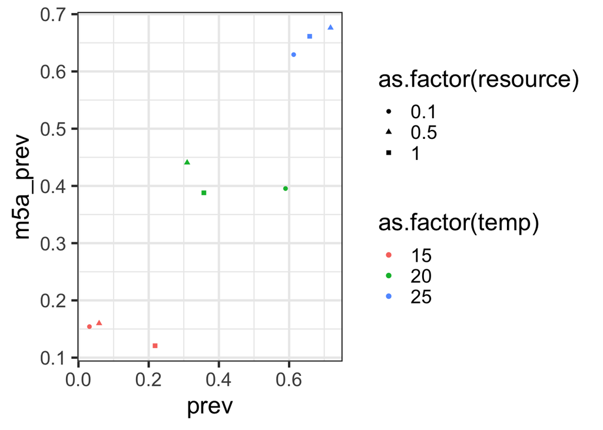

```r
mod_params %>% ggplot(.,aes(x=prev, y=1-exp(-f*((m5a_u*exp((m5a_arr+m5a_p*resource)*(1/ref_t-1/temp))*resource)/
                                             (m5a_k + resource))*z), color = as.factor(temp), shape = as.factor(resource))) + geom_point() + labs(y = "m5a_prev")
```

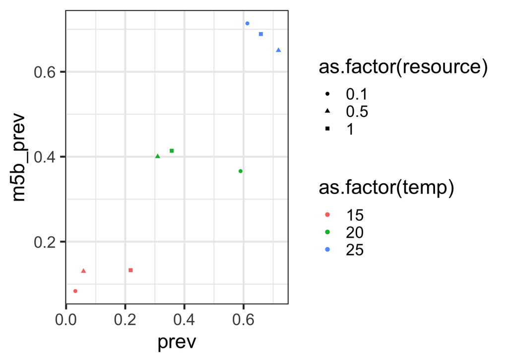

```r
mod_params %>% ggplot(.,aes(x=prev, y=1-exp(-f*(m5b_u*exp((m5b_arr*exp(m5b_p*resource))*(1/ref_t-1/temp))*resource/
                                             (m5b_k + resource))*z), color = as.factor(temp), shape = as.factor(resource))) + geom_point() + labs(y = "m5b_prev")
```

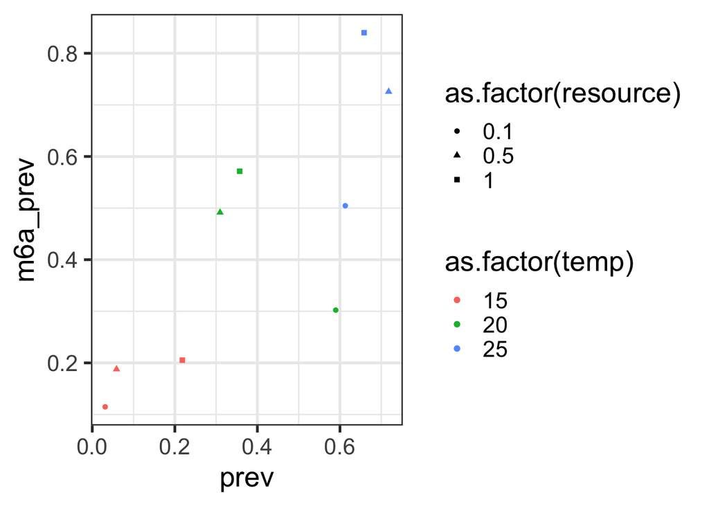

```r
mod_params %>% ggplot(.,aes(x=prev, y=1-exp(-f*((m6a_u*exp((m6a_arr)*(1/ref_t-1/temp))*resource)/
                                             (m6a_k + m6a_w*resource))*z), color = as.factor(temp), shape = as.factor(resource))) + geom_point() + labs(y = "m6a_prev")
```

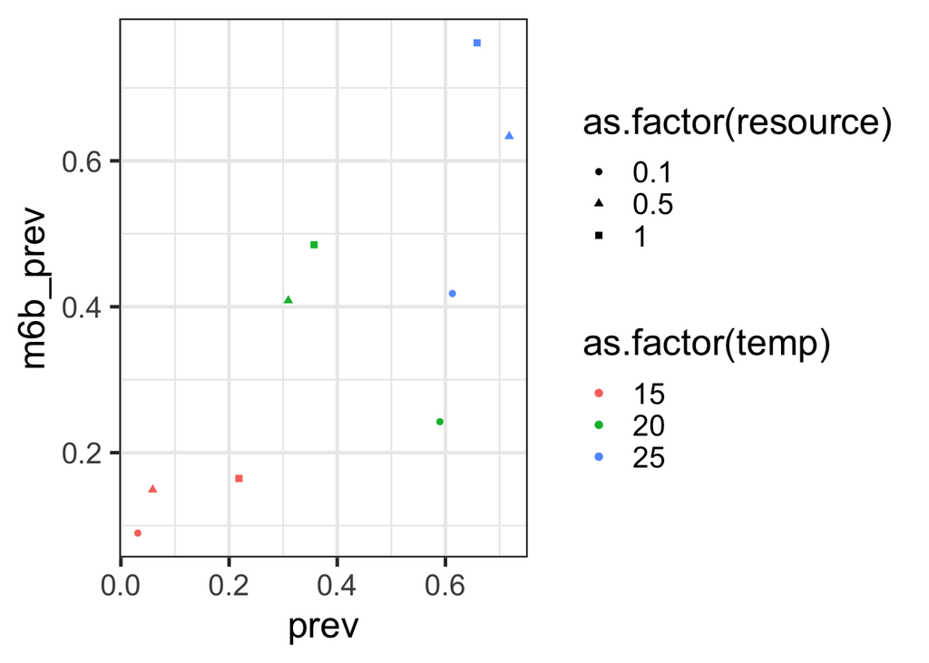

```r
mod_params %>% ggplot(.,aes(x=prev, y=1-exp(-f*(m6b_u*exp((m6b_arr)*(1/ref_t-1/temp))*resource/
                                             (m6b_k*exp(m6b_w*resource)))*z), color = as.factor(temp), shape = as.factor(resource))) + geom_point() + labs(y = "m6b_prev")
```

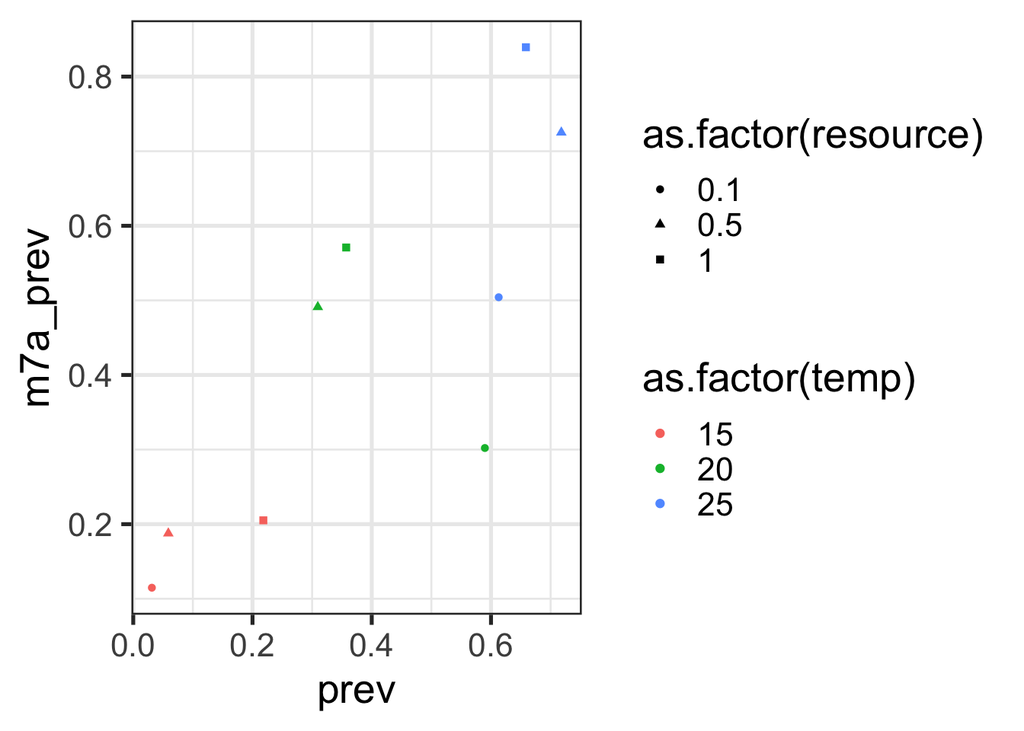

```r
mod_params %>% ggplot(.,aes(x=prev, y=1-exp(-f*((m7a_u*exp((m7a_arr+m7a_p*resource)*(1/ref_t-1/temp))*resource)/
                                             (m7a_k + m7a_w*resource))*z), color = as.factor(temp), shape = as.factor(resource))) + geom_point() + labs(y = "m7a_prev")
```

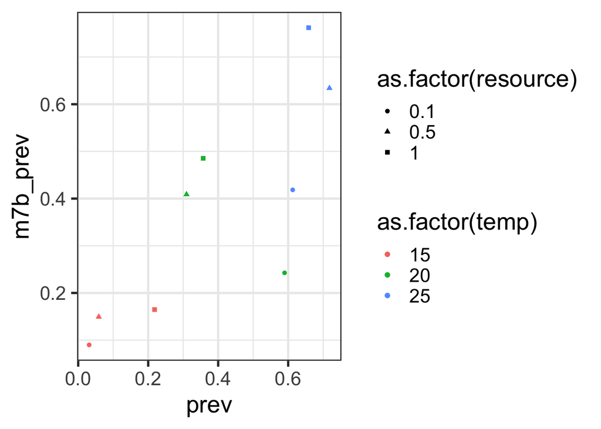

```r
mod_params %>% ggplot(.,aes(x=prev, y=1-exp(-f*(m7b_u*exp((m7b_arr*exp(m7b_p*resource))*(1/ref_t-1/temp))*resource/
                                             (m7b_k*exp(m7b_w*resource)))*z), color = as.factor(temp), shape = as.factor(resource))) + geom_point() + labs(y = "m7b_prev")
```

```r
mod_list <- list(m1_u_fit, m2_u_fit, m3_u_fit, m4_u_fit,
                 m5a_u_fit, m5b_u_fit, m6a_u_fit, m6b_u_fit,
                 m7a_u_fit, m7b_u_fit)

mod_names <- c("m1", "m2", "m3", "m4",
               "m5a", "m5b", "m6a", "m6b",
               "m7a", "m7b")
mod_names_descriptive <- c("size", "temp", "rsc", "full",
                           "arr(R)~LIN", "arr(R)~EXP", "h(T)~LIN", "h(T)~EXP",
                           "LIN-LIN", "EXP_EXP")
mod_names_full <- paste(mod_names, mod_names_descriptive, sep="_")

AICtab(mod_list, logLik=T, base=T, mnames=mod_names_full, weights=T)
```

```
##                logLik AIC    dLogLik dAIC   df weight
## m3_rsc         -194.4  392.8   22.5     0.0 2  0.347
## m5b_arr(R)~EXP -192.7  393.3   24.3     0.5 4  0.271
## m4_full        -194.2  394.4   22.7     1.6 3  0.156
## m6b_h(T)~EXP   -194.1  396.1   22.9     3.3 4  0.067
## m6a_h(T)~LIN   -194.1  396.2   22.8     3.4 4  0.063
## m5a_arr(R)~LIN -194.4  396.7   22.6     3.9 4  0.049
## m7b_EXP_EXP    -194.1  398.1   22.9     5.3 5  0.025
## m7a_LIN-LIN    -194.1  398.2   22.8     5.4 5  0.023
## m1_size        -216.9  435.9    0.0    43.1 1  <0.001
## m2_temp        -216.7  437.4    0.3    44.5 2  <0.001
```

```r
temp_range <- seq(15,25,by=0.1)
resource_range <- seq(0.1,1,by=0.01)

seq_data <- tibble(temp=c(),
                   resourece=c())

for (i in 1:length(temp_range)){
  tmp <- tibble(temp = temp_range[i],
                resource = seq(0.1,1,by=0.01))
  seq_data %<>% bind_rows(., tmp)
}


seq_data %<>% mutate(temp_factor = case_when(temp==15 ~ 15,
                                             temp==20 ~ 20,
                                             temp==25 ~ 25))
```

```r
m1_u = coef(m1_u_fit)[1]
m2_u = coef(m2_u_fit)[1]
m2_arr = coef(m2_u_fit)[2]
m3_u = coef(m3_u_fit)[1]
m3_k = coef(m3_u_fit)[2]
m4_u = coef(m4_u_fit)[1]
m4_arr = coef(m4_u_fit)[2]
m4_k = coef(m4_u_fit)[3]
m5a_u = coef(m5a_u_fit)[1]
m5a_arr = coef(m5a_u_fit)[2]
m5a_k = coef(m5a_u_fit)[3]
m5a_p = coef(m5a_u_fit)[4]
m5b_u = coef(m5b_u_fit)[1]
m5b_arr = coef(m5b_u_fit)[2]
m5b_k = coef(m5b_u_fit)[3]
m5b_p = coef(m5b_u_fit)[4]
m6a_u = coef(m6a_u_fit)[1]
m6a_arr = coef(m6a_u_fit)[2]
m6a_k = coef(m6a_u_fit)[3]
m6a_w = coef(m6a_u_fit)[4]
m6b_u = coef(m6b_u_fit)[1]
m6b_arr = coef(m6b_u_fit)[2]
m6b_k = coef(m6b_u_fit)[3]
m6b_w = coef(m6b_u_fit)[4]
m7a_u = coef(m7a_u_fit)[1]
m7a_arr = coef(m7a_u_fit)[2]
m7a_k = coef(m7a_u_fit)[3]
m7a_p = coef(m7a_u_fit)[4]
m7a_w = coef(m7a_u_fit)[5]
m7b_u = coef(m7b_u_fit)[1]
m7b_arr = coef(m7b_u_fit)[2]
m7b_k = coef(m7b_u_fit)[3]
m7b_p = coef(m7b_u_fit)[4]
m7b_w = coef(m7b_u_fit)[5]
```

```r
seq_data %<>% mutate(#f = f_median,
                     f = get_f(seq_data$temp, seq_data$resource),
                     m1_prev = 1-exp(-f*m1_u*z),
                     m2_prev = 1-exp(-f*m2_u*z*exp(m2_arr*(1/ref_t-1/temp))),
                     m3_prev = 1-exp(-f*(m3_u*resource/(m3_k + resource))*z),
                     m4_prev = 1-exp(-f*(m4_u*exp(m4_arr*(1/ref_t-1/temp))*resource/
                                                           (m4_k + resource))*z),
                     m5a_prev = 1-exp(-f*((m5a_u*exp((m5a_arr+m5a_p*resource)*(1/ref_t-1/temp))*resource)/
                                             (m5a_k + resource))*z),
                     m5b_prev = 1-exp(-f*(m5b_u*exp((m5b_arr*exp(m5b_p*resource))*(1/ref_t-1/temp))*resource/
                                             (m5b_k + resource))*z),
                     m6a_prev = 1-exp(-f*((m6a_u*exp((m6a_arr)*(1/ref_t-1/temp))*resource)/
                                             (m6a_k + m6a_w*resource))*z),
                     m6b_prev = 1-exp(-f*(m6b_u*exp((m6b_arr)*(1/ref_t-1/temp))*resource/
                                             (m6b_k*exp(m6b_w*resource)))*z),
                     m7a_prev = 1-exp(-f*((m7a_u*exp((m7a_arr+m7a_p*resource)*(1/ref_t-1/temp))*resource)/
                                             (m7a_k + m7a_w*resource))*z),
                     m7b_prev = 1-exp(-f*(m7b_u*exp((m7b_arr*exp(m7b_p*resource))*(1/ref_t-1/temp))*resource/
                                             (m7b_k*exp(m7b_w*resource)))*z))
```

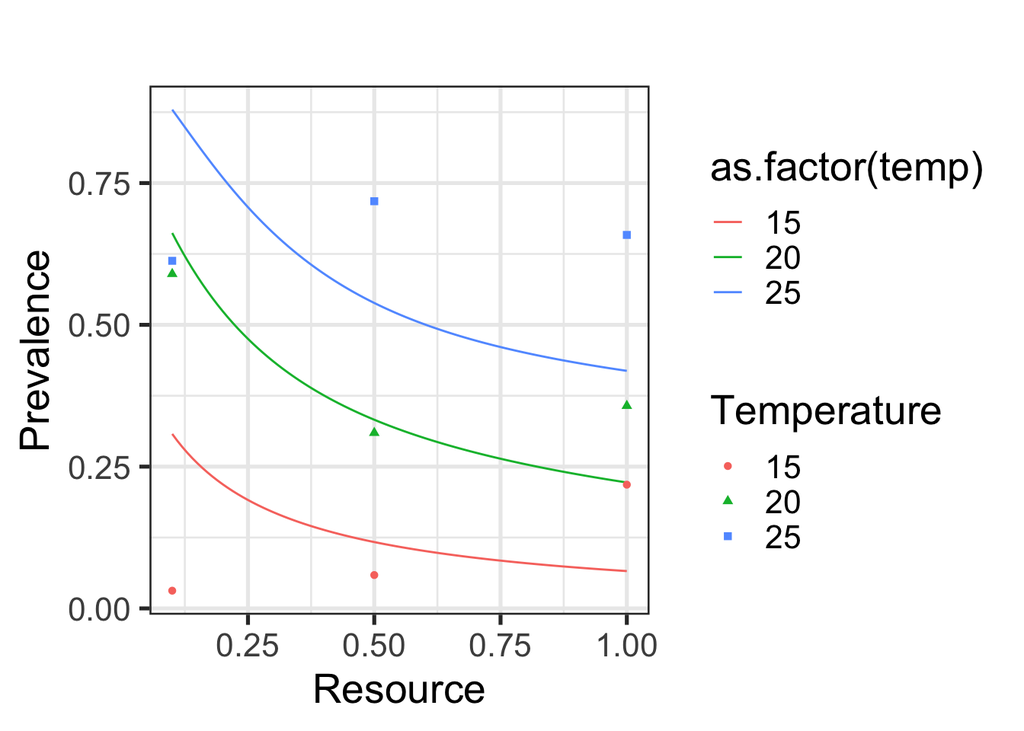

```r
seq_data %>% filter(temp %in% c(15, 20, 25)) %>%
ggplot(.) +
geom_line(aes(x=resource,
              y=m1_prev,
              group=temp,
              color=as.factor(temp))) +
new_scale_color() +
geom_point(data=beta_summ, aes(x=resource,
                          y=prev,
                          group = as.factor(temp),
                          color = as.factor(temp),
                          shape = as.factor(temp))) +
labs(x="Resource", y="Prevalence", color="Temperature", shape="Temperature", title = "")
```

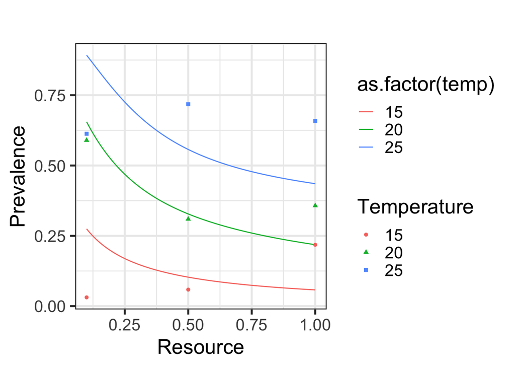

```r
seq_data %>% filter(temp %in% c(15, 20, 25)) %>%
ggplot(.) +
geom_line(aes(x=resource,
              y=m2_prev,
              group=temp,
              color=as.factor(temp))) +
new_scale_color() +
geom_point(data=beta_summ, aes(x=resource,
                          y=prev,
                          group = as.factor(temp),
                          color = as.factor(temp),
                          shape = as.factor(temp))) +
labs(x="Resource", y="Prevalence", color="Temperature", shape="Temperature", title = "")
```

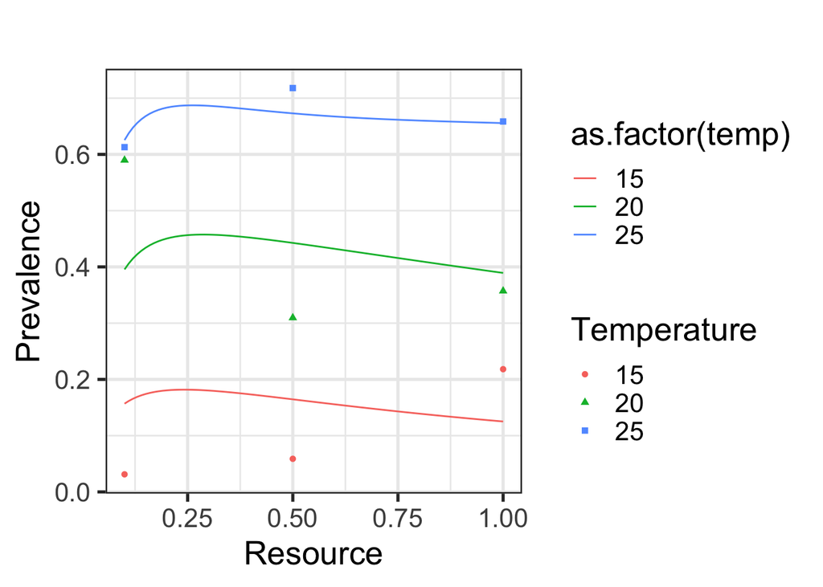

```r
seq_data %>% filter(temp %in% c(15, 20, 25)) %>%
ggplot(.) +
geom_line(aes(x=resource,
              y=m3_prev,
              group=temp,
              color=as.factor(temp))) +
new_scale_color() +
geom_point(data=beta_summ, aes(x=resource,
                          y=prev,
                          group = as.factor(temp),
                          color = as.factor(temp),
                          shape = as.factor(temp))) +
labs(x="Resource", y="Prevalence", color="Temperature", shape="Temperature", title = "")
```

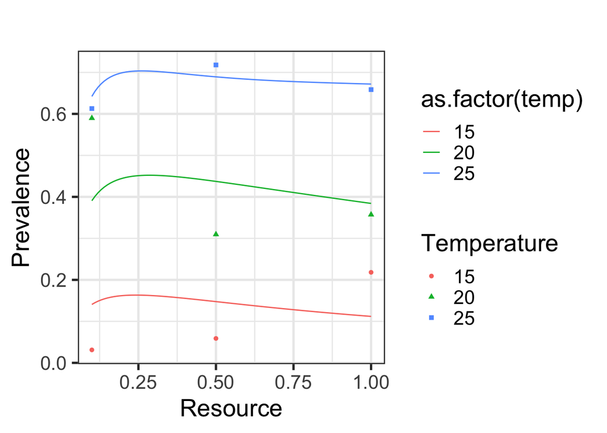

```r
seq_data %>% filter(temp %in% c(15, 20, 25)) %>%
ggplot(.) +
geom_line(aes(x=resource,
              y=m4_prev,
              group=temp,
              color=as.factor(temp))) +
new_scale_color() +
geom_point(data=beta_summ, aes(x=resource,
                          y=prev,
                          group = as.factor(temp),
                          color = as.factor(temp),
                          shape = as.factor(temp))) +
labs(x="Resource", y="Prevalence", color="Temperature", shape="Temperature", title = "")
```

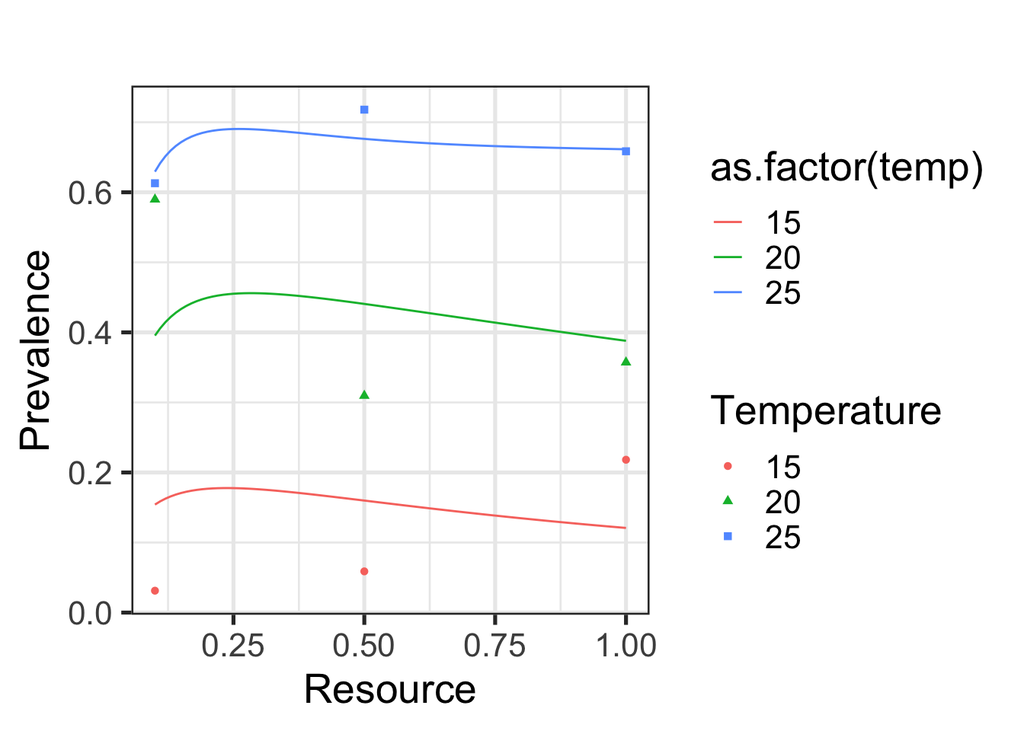

```r
seq_data %>% filter(temp %in% c(15, 20, 25)) %>%
ggplot(.) +
geom_line(aes(x=resource,
              y=m5a_prev,
              group=temp,
              color=as.factor(temp))) +
new_scale_color() +
geom_point(data=beta_summ, aes(x=resource,
                          y=prev,
                          group = as.factor(temp),
                          color = as.factor(temp),
                          shape = as.factor(temp))) +
labs(x="Resource", y="Prevalence", color="Temperature", shape="Temperature", title = "")
```

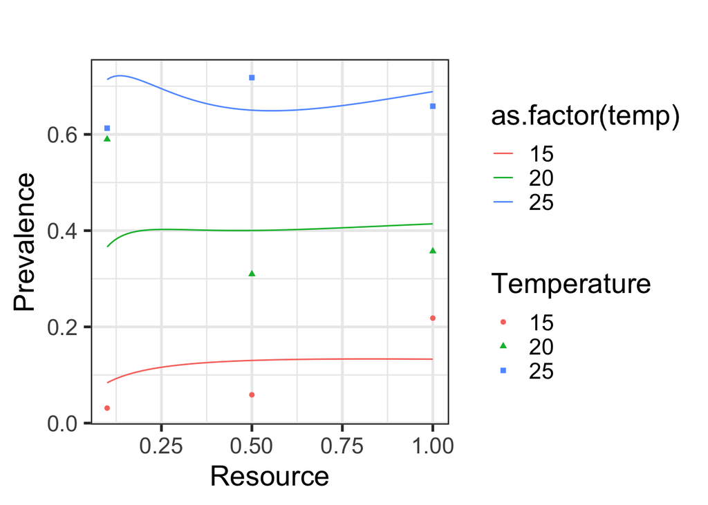

```r
seq_data %>% filter(temp %in% c(15, 20, 25)) %>%
ggplot(.) +
geom_line(aes(x=resource,
              y=m5b_prev,
              group=temp,
              color=as.factor(temp))) +
new_scale_color() +
geom_point(data=beta_summ, aes(x=resource,
                          y=prev,
                          group = as.factor(temp),
                          color = as.factor(temp),
                          shape = as.factor(temp))) +
labs(x="Resource", y="Prevalence", color="Temperature", shape="Temperature", title = "")
```

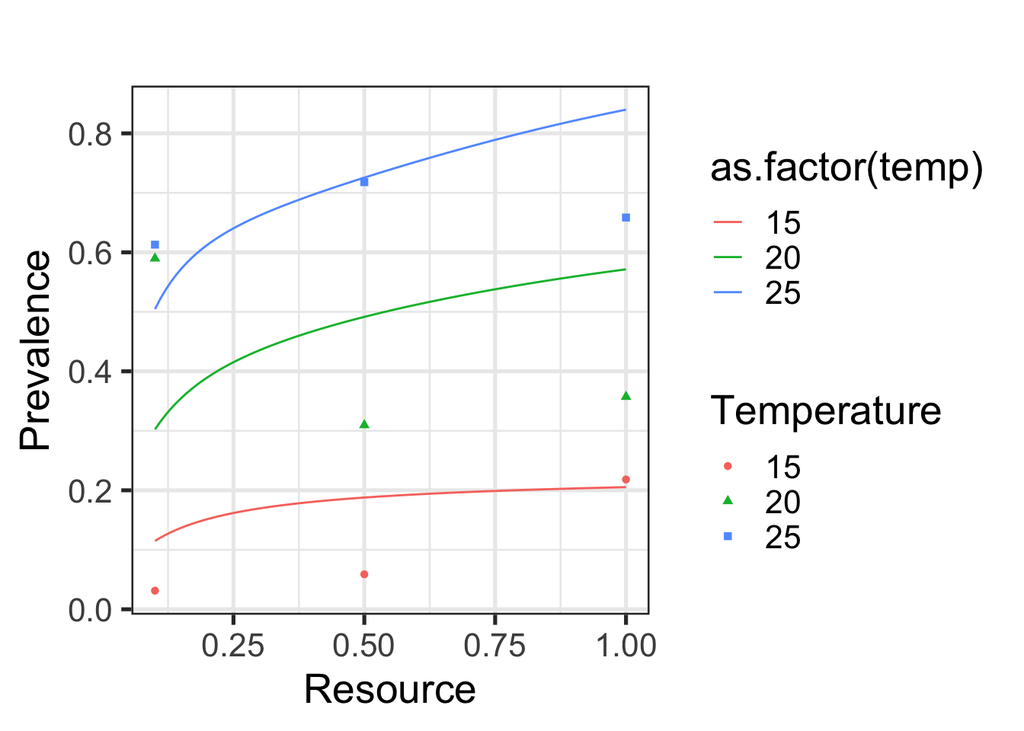

```r
seq_data %>% filter(temp %in% c(15, 20, 25)) %>%
ggplot(.) +
geom_line(aes(x=resource,
              y=m6a_prev,
              group=temp,
              color=as.factor(temp))) +
new_scale_color() +
geom_point(data=beta_summ, aes(x=resource,
                          y=prev,
                          group = as.factor(temp),
                          color = as.factor(temp),
                          shape = as.factor(temp))) +
labs(x="Resource", y="Prevalence", color="Temperature", shape="Temperature", title = "")
```

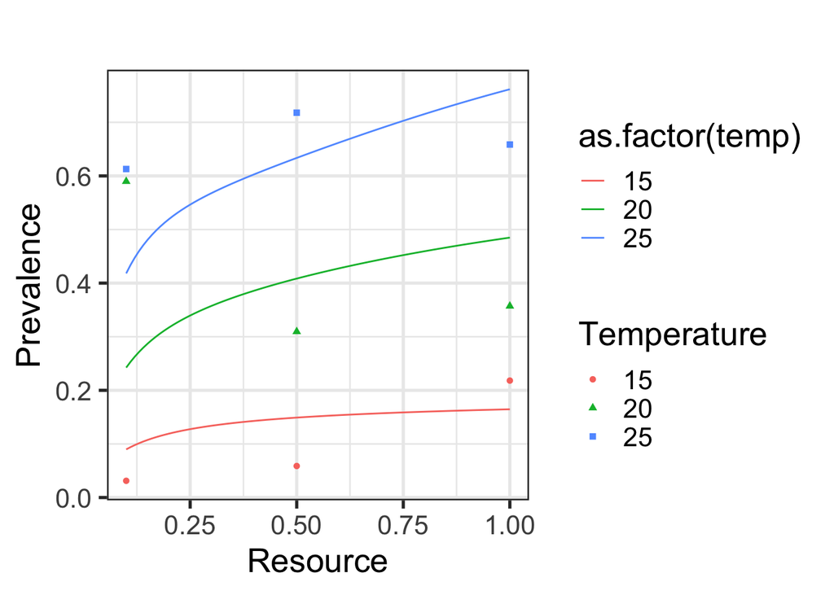

```r
seq_data %>% filter(temp %in% c(15, 20, 25)) %>%
ggplot(.) +
geom_line(aes(x=resource,
              y=m6b_prev,
              group=temp,
              color=as.factor(temp))) +
new_scale_color() +
geom_point(data=beta_summ, aes(x=resource,
                          y=prev,
                          group = as.factor(temp),
                          color = as.factor(temp),
                          shape = as.factor(temp))) +
labs(x="Resource", y="Prevalence", color="Temperature", shape="Temperature", title = "")
```

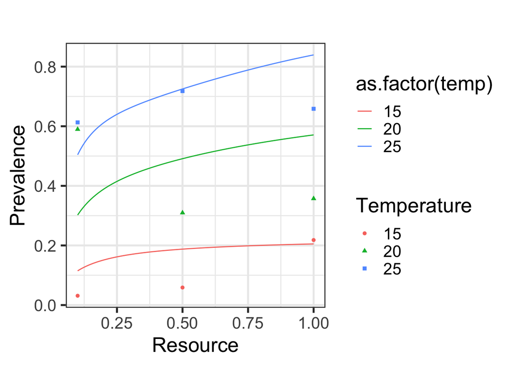

```r
seq_data %>% filter(temp %in% c(15, 20, 25)) %>%
ggplot(.) +
geom_line(aes(x=resource,
              y=m7a_prev,
              group=temp,
              color=as.factor(temp))) +
new_scale_color() +
geom_point(data=beta_summ, aes(x=resource,
                          y=prev,
                          group = as.factor(temp),
                          color = as.factor(temp),
                          shape = as.factor(temp))) +
labs(x="Resource", y="Prevalence", color="Temperature", shape="Temperature", title = "")
```

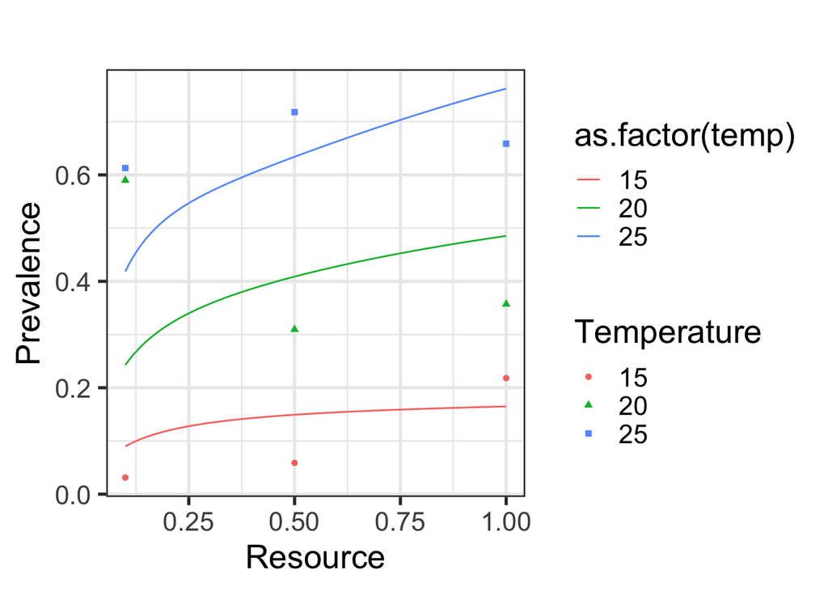

```r
seq_data %>% filter(temp %in% c(15, 20, 25)) %>%
ggplot(.) +
geom_line(aes(x=resource,
              y=m7b_prev,
              group=temp,
              color=as.factor(temp))) +
new_scale_color() +
geom_point(data=beta_summ, aes(x=resource,
                          y=prev,
                          group = as.factor(temp),
                          color = as.factor(temp),
                          shape = as.factor(temp))) +
labs(x="Resource", y="Prevalence", color="Temperature", shape="Temperature", title = "")
```